# Linear Regression

Mendoza College of Business

10/18/2021

## Linear Regression

- Apply simple linear regression
- Apply multiple linear regression
- Create interaction terms in linear regression
- Interpret the output of linear regression

## Preliminary Steps

We first need to load our data into the R environment. The data is stored in a file called `insurance_dat.rda`.

```r
load("insurance_dat.rda") # Load Dataset
```

We also need to load the packages which we are going to use for this analysis into R.

```r
library(ggplot2) # Load ggplot for plotting
```

```r
dim(insurance) # Check dimensions of dataset
```

```
## [1] 1338    7
```

```r
head(insurance) # View head of dataset (First rows)
```

```
##   age    sex    bmi children smoker    region   charges
## 1  19 female 27.900        0    yes southwest 16884.924
## 2  18   male 33.770        1     no southeast  1725.552
## 3  28   male 33.000        3     no southeast  4449.462
## 4  33   male 22.705        0     no northwest 21984.471
## 5  32   male 28.880        0     no northwest  3866.855
## 6  31 female 25.740        0     no southeast  3756.622
```

```r
tail(insurance) # View tail of dataset (Last rows)
```

```
##      age    sex   bmi children smoker    region   charges
## 1333  52 female 44.70        3     no southwest 11411.685
## 1334  50   male 30.97        3     no northwest 10600.548
## 1335  18 female 31.92        0     no northeast  2205.981
## 1336  18 female 36.85        0     no southeast  1629.833
## 1337  21 female 25.80        0     no southwest  2007.945
## 1338  61 female 29.07        0    yes northwest 29141.360
```

- age - The age of the individual.
- sex - The sex of the individual.
- bmi - The body mass index of the individual
- children - The number of children the individual has
- smoker - Yes/No if the individual is a smoker
- region - The region of the country the individual comes from
- charges - The insurance premium for the individual

Let’s check that we have no duplicated samples in the dataset:

```r
nrow(unique(insurance)) # Check unique rows in dataset
```

```
## [1] 1337
```

It looks like there is one duplicated sample in the dataset, we can remove this by running:

```r
# Only select rows which are not duplicated
insurance <- insurance[!duplicated(insurance),]
```

We can also examine the dataset using the `summary()` command:

```r
summary(insurance)
```

```
##       age            sex           bmi           children     smoker
##  Min.   :18.00   female:662   Min.   :15.96   Min.   :0.000   no :1063
##  1st Qu.:27.00   male  :675   1st Qu.:26.29   1st Qu.:0.000   yes: 274
##  Median :39.00                Median :30.40   Median :1.000
##  Mean   :39.22                Mean   :30.66   Mean   :1.096
##  3rd Qu.:51.00                3rd Qu.:34.70   3rd Qu.:2.000
##  Max.   :64.00                Max.   :53.13   Max.   :5.000
##        region       charges
##  northeast:324   Min.   : 1122
##  northwest:324   1st Qu.: 4746
##  southeast:364   Median : 9386
##  southwest:325   Mean   :13279
##                  3rd Qu.:16658
##                  Max.   :63770
```

## Investigate Response Variable

Next we want to have a look at the response variable we are using:

```r
# Summarize charges column
summary(insurance$charges)
```

```
##    Min. 1st Qu.  Median    Mean 3rd Qu.    Max.
##    1122    4746    9386   13279   16658   63770
```

As this is a numeric variable the `summary()` command returns the minimum, 1st quartile value, median, mean, 3rd quartile value, and the maximum value. From this we can see that the median and mean values fall around 10,000 to 13,000.

For situations where the mean is greater than the median this may indicate the presence of positive outliers in the dataset.

To get a better idea of how the insurance charges are distributed we can plot a density plot of the charges in the dataset:

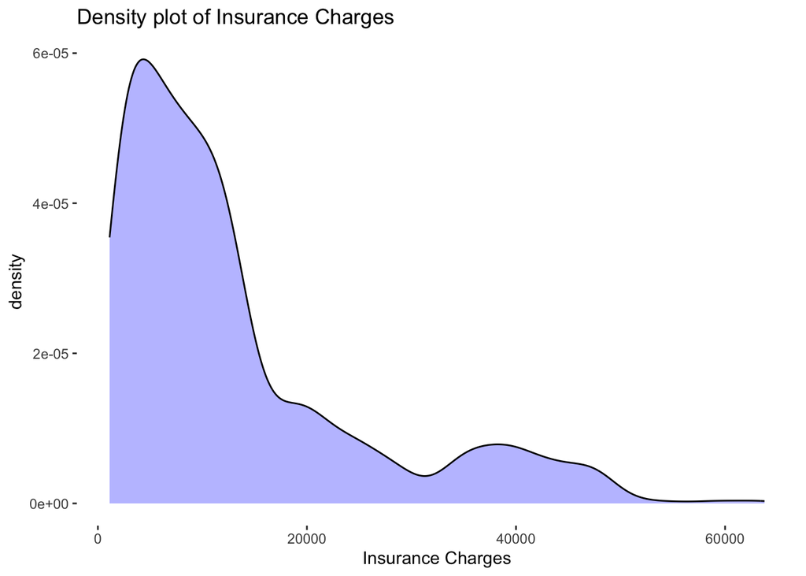

```r
# Create plot
g_1 <- ggplot(insurance, aes(x = charges)) + # Set X-axis as insurance charges
  geom_density(fill = "blue", alpha = 0.3) + # Use geom_density to get density plot
  theme_bw() + # Set theme for plot
  theme(panel.grid.major = element_blank(), # Turn of the background grid
        panel.grid.minor = element_blank(),
        panel.border = element_blank(),
        panel.background = element_blank()) +
  labs(x = "Insurance Charges", # Set plot labels
       title = "Density plot of Insurance Charges")

g_1 # Generate plot
```

Here we can see that the majority of the samples pay an insurance charges of less than $20,000 while some individuals pay extreme charges of greater than $60,000.

This is a quite skewed distribution.

## Log-transform

To provide a more meaningful response variable and reduce the effect of outliers we can transform the data. One way to do this is to use log transform. Log transform reduces the variance of very high values in the dataset and is often useful for dealing with skewed variables. Look what happens when we log transform the values of 1, 10, 100, 1,000, and 10,000.

```r
log(1) # Return log 1
```

```
## [1] 0
```

```r
log(10) # Return log 10
```

```
## [1] 2.302585
```

```r
log(100) # Return log 100
```

```
## [1] 4.60517
```

```r
log(1000) # Return log 1000
```

```
## [1] 6.907755
```

```r
log(10000) # Return log 10000
```

```
## [1] 9.21034
```

```r
log(100000) # Return log 100000
```

```
## [1] 11.51293
```

Here we see that all the variables are now less than 12. Note that as the log transform value of 1 is 0 we will add 1 to each of the values prior to log transforming them:

```r
log_charges <- log(insurance$charges + 1) # Log transform insurance charges

summary(log_charges) # Summarize log transformed variable
```

```
##    Min. 1st Qu.  Median    Mean 3rd Qu.    Max.
##   7.024   8.465   9.147   9.100   9.721  11.063
```

```r
insurance$log_charges <- log_charges # Add variable to dataset
```

Here we see that the logged charges now range from 7 to 11.063. Now lets try plotting our transformed variable:

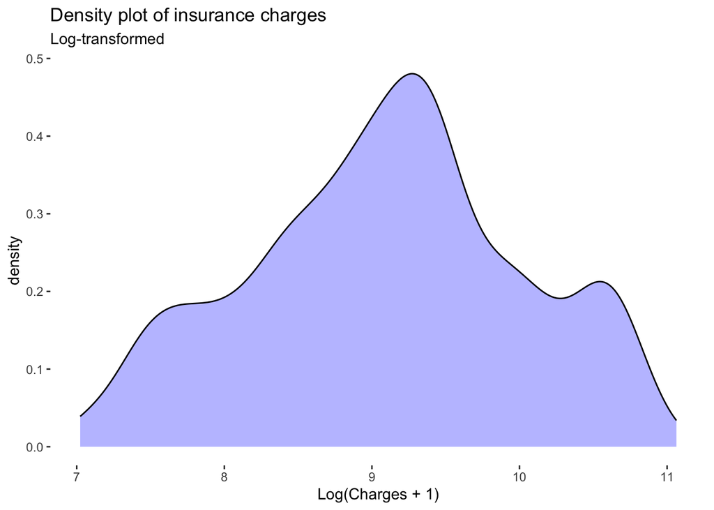

```r
g_2 <- ggplot(insurance, aes(x = log_charges)) + # Set X-axis as the log of insurance charges
  geom_density(fill = "blue", alpha = 0.3) + # Use geom_density to get density plot
  theme_bw() + # Set theme for plot
  theme(panel.grid.major = element_blank(), # Turn of the background grid
        panel.grid.minor = element_blank(),
        panel.border = element_blank(),
        panel.background = element_blank()) +
  labs(x = "Log(Charges + 1)", # Set plot labels
       title = "Density plot of insurance charges",
       subtitle = "Log-transformed")

g_2 # Generate plot
```

This looks a lot closer to normal, not perfect, but an improvement over the previous response.

## First Model

As a first attempt at determining the factors involved in insurance prices let’s look at the age of the individual. We hypothesize that higher age leads to a higher price for health insurance given the medical complications that come with old age. First let’s create a scatter plot of the log transformed charges vs the age of the individual:

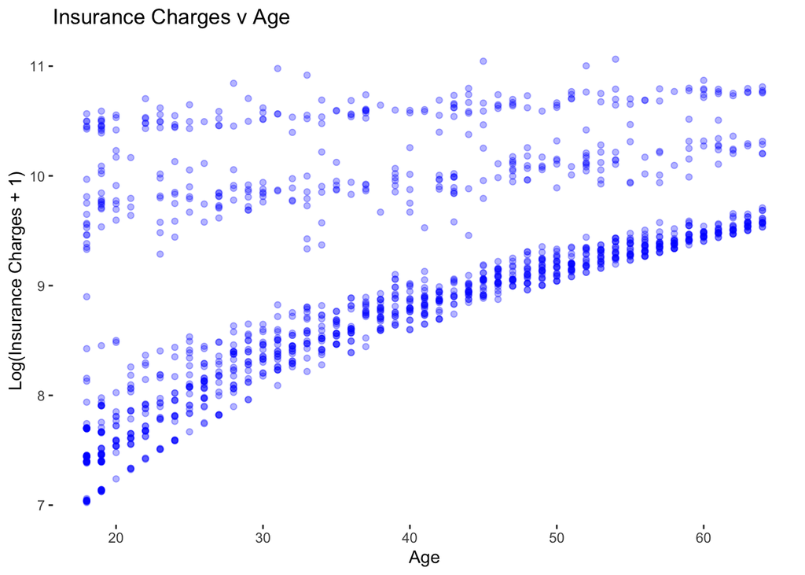

```r
# Create plot
g_3 <- ggplot(insurance, # Set dataset
              aes(y = log_charges, # Set y-axis as insurance charges
                  x = age)) + # Set x-axis as age.
  geom_point(color = "blue", alpha = 0.3) + # Use geom_point to get scatter plot
  theme_bw() + # Set theme for plot
  theme(panel.grid.major = element_blank(), # Turn of the background grid
        panel.grid.minor = element_blank(),
        panel.border = element_blank(),
        panel.background = element_blank()) +
  labs(y = "Log(Insurance Charges + 1)", # Set plot labels
       x = "Age",
       title = "Insurance Charges v Age")

g_3 # Generate plot
```

It looks like there is a positive relationship between age and insurance charges, let’s add a smoothing line, `geom_smooth()` to identify patterns in the relationship.

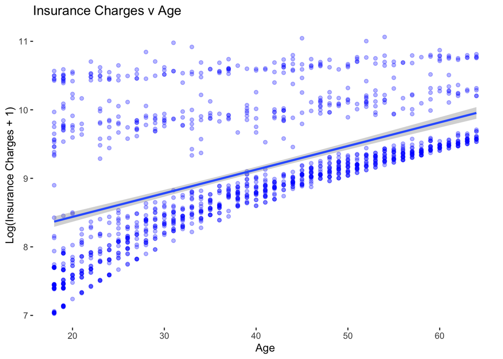

```r
# Create plot
g_4 <- ggplot(insurance, # Set dataset
              aes(y = log_charges, # Set y-axis as insurance charges
                  x = age)) + # Set x-axis as age.
  geom_point(color = "blue", alpha = 0.3) + # Use geom_point to get scatter plot
  geom_smooth(method = "lm") + # Add smoothing line
  theme_bw() + # Set theme for plot
  theme(panel.grid.major = element_blank(), # Turn of the background grid
        panel.grid.minor = element_blank(),
        panel.border = element_blank(),
        panel.background = element_blank()) +
  labs(y = "Log(Insurance Charges + 1)", # Set plot labels
       x = "Age",
       title = "Insurance Charges v Age")

g_4 # Generate plot
```

From this it does look like there is quite a significant relationship between the variables with those of higher ages paying a higher premium.

Lets try fitting a model and see what the results say.

### Fitting a linear regression model

To fit a linear regression model we use the `lm` command. Inside this function we need to set the formula which is in the form of “response variable ~ explanatory variables”, in our case this is `log_charges ~ age`. We also need to specify the dataset which we are using for the model, `insurance`.

```r
fit_1 <- lm(log_charges ~ age, # Set formula
            data = insurance) # Set dataset
```

We can then access the results of our model by running the summary command on the fitted model:

```r
summary(fit_1)
```

```
##
## Call:
## lm(formula = log_charges ~ age, data = insurance)
##
## Residuals:
##     Min      1Q  Median      3Q     Max
## -1.3451 -0.4160 -0.3095  0.5015  2.1973
##
## Coefficients:
##             Estimate Std. Error t value Pr(>|t|)
## (Intercept) 7.748453   0.063380  122.25   <2e-16 ***
## age         0.034461   0.001521   22.65   <2e-16 ***
## ---
## Signif. codes:  0 '***' 0.001 '**' 0.01 '*' 0.05 '.' 0.1 ' ' 1
##
## Residual standard error: 0.781 on 1335 degrees of freedom
## Multiple R-squared:  0.2776, Adjusted R-squared:  0.2771
## F-statistic: 513.1 on 1 and 1335 DF,  p-value: < 2.2e-16
```

# More variables

To try improve our model fit lets add some variables to the model. First lets look at the distributions of the variables and see if we need to transform them, then view their relationship with the insurance premium.

```r
summary(insurance$sex) # Summarize sex variable
```

```
## female   male
##    662    675
```

```r
summary(insurance$bmi) # Summarize BMI variable
```

```
##    Min. 1st Qu.  Median    Mean 3rd Qu.    Max.
##   15.96   26.29   30.40   30.66   34.70   53.13
```

```r
summary(insurance$children) # Summarize children variable
```

```
##    Min. 1st Qu.  Median    Mean 3rd Qu.    Max.
##   0.000   0.000   1.000   1.096   2.000   5.000
```

```r
summary(insurance$smoker) # Summarize smoker variable
```

```
##   no  yes
## 1063  274
```

```r
summary(insurance$region) # Summarize region variable
```

```
## northeast northwest southeast southwest
##       324       324       364       325
```

Let’s first generate scatter plots of the relationship between charges and the numeric variables:

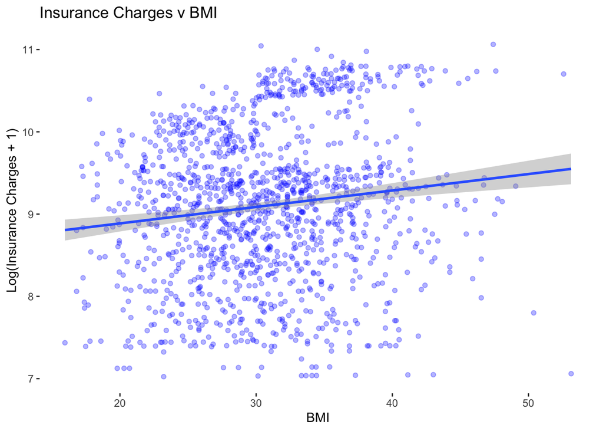

```r
# Create plot
g_5 <- ggplot(insurance, # Set dataset
              aes(y = log_charges, # Set y-axis as insurance charges
                  x = bmi)) + # Set x-axis as bmi.
  geom_point(color = "blue", alpha = 0.3) + # Use geom_point to get scatter plot
  geom_smooth(method = "lm") + # Add smoothing line
  theme_bw() + # Set theme for plot
  theme(panel.grid.major = element_blank(), # Turn of the background grid
        panel.grid.minor = element_blank(),
        panel.border = element_blank(),
        panel.background = element_blank()) +
  labs(y = "Log(Insurance Charges + 1)", # Set plot labels
       x = "BMI",
       title = "Insurance Charges v BMI")

g_5 # Generate plot
```

It looks like BMI has a slightly positive relationship with insurance charges.

Next let’s look at the relationship with the number of children:

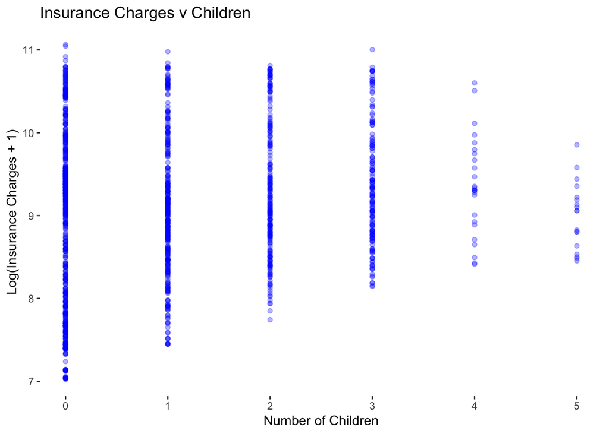

```r
# Create plot
g_6 <- ggplot(insurance, # Set dataset
              aes(y = log_charges, # Set y-axis as insurance charges
                  x = children)) + # Set x-axis as number of children.
  geom_point(color = "blue", alpha = 0.3) + # Use geom_point to get scatter plot
  geom_smooth() + # Add smoothing line
  theme_bw() + # Set theme for plot
  theme(panel.grid.major = element_blank(), # Turn of the background grid
        panel.grid.minor = element_blank(),
        panel.border = element_blank(),
        panel.background = element_blank()) +
  labs(y = "Log(Insurance Charges + 1)", # Set plot labels
       x = "Number of Children",
       title = "Insurance Charges v Children")

g_6 # Generate plot
```

Since there are only a few levels in the children variable this is not a great view of the data. Instead of a scatter plot let’s create a box plot. Here we will wrap children in `factor()` when setting the aesthetic so that ggplot treats it as a categorical variable:

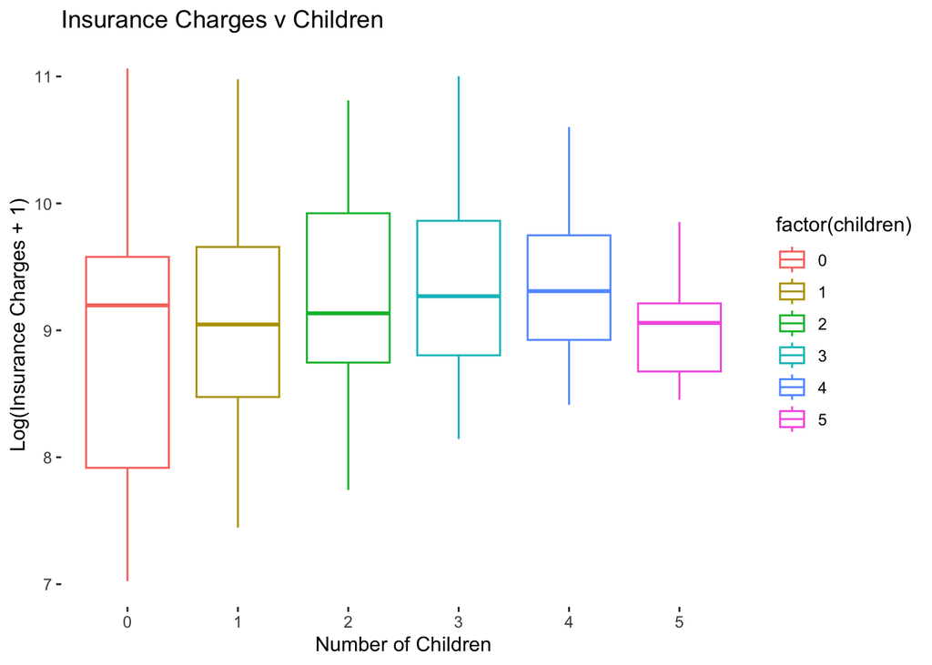

```r
# Create plot
g_7 <- ggplot(insurance, # Set dataset
              aes(y = log_charges, # Set y-axis as insurance charges
                  x = factor(children), # Set x-axis as children converted to factor.
                  color = factor(children))) + # Set color as children converted to factor.
  geom_boxplot(alpha = 0.7) + # Use geom_boxplot to get  boxplot
  theme_bw() + # Set theme for plot
  theme(panel.grid.major = element_blank(), # Turn of the background grid
        panel.grid.minor = element_blank(),
        panel.border = element_blank(),
        panel.background = element_blank()) +
  labs(y = "Log(Insurance Charges + 1)", # Set plot labels
       x = "Number of Children",
       title = "Insurance Charges v Children")

g_7 # Generate plot
```

There does not appear to be much of a relationship here, perhaps a slight increase as the number of children increases above 0.

Note here that we have several categorical variables and so we cannot use scatter plots to visualize the relationship, instead we can use layered density plots.

Let’s first look at the relationship between sex and charges, here we will set `fill` equal to sex and set the fill values manually:

```r
g_8 <- ggplot(insurance, aes(x = log_charges, # Set X-axis as the log of insurance charges
                             fill = sex)) + # Set fill as sex variable
  geom_density(alpha = 0.3) + # Use geom_density to get density plot
  theme_bw() + # Set theme for plot
  theme(panel.grid.major = element_blank(), # Turn of the background grid
        panel.grid.minor = element_blank(),
        panel.border = element_blank(),
        panel.background = element_blank()) +
  scale_fill_manual(values =  c("female" = "blue", "male" = "red")) # Set fill values manually
  labs(x = "Log(Charges + 1)", # Set plot labels
       title = "Density plot of insurance charges vs Sex",
       fill = "Sex",
       subtitle = "Log-transformed")
```

```
## $x
## [1] "Log(Charges + 1)"
##
## $fill
## [1] "Sex"
##
## $title
## [1] "Density plot of insurance charges vs Sex"
##
## $subtitle
## [1] "Log-transformed"
##
## attr(,"class")
## [1] "labels"
```

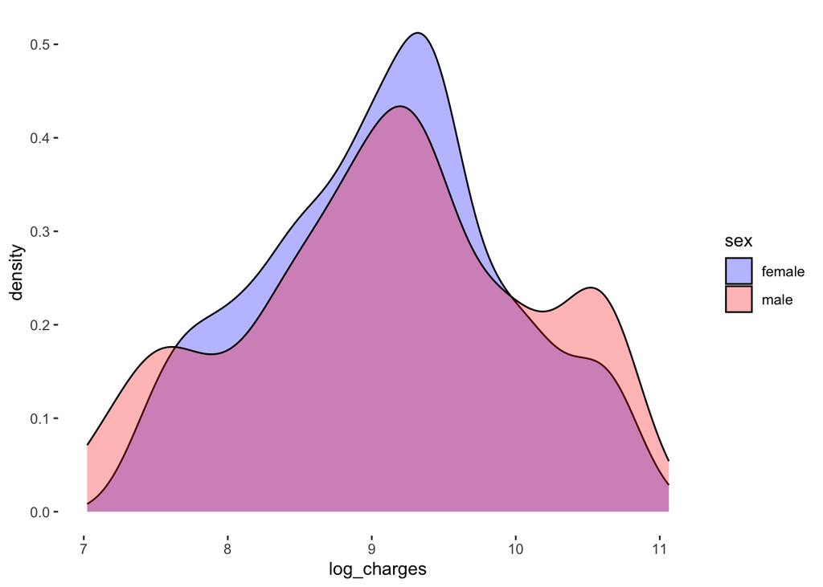

```r
g_8 # Generate plot
```

Here we see that there is not much separation between the two distributions, with men having more extreme values of each side. This is not likely to be a significant variable.

Next up let’s visualize the relationship between smoking and insurance charges:

```r
g_9 <- ggplot(insurance, aes(x = log_charges, # Set X-axis as the log of insurance charges
                             fill = smoker)) + # Set fill as smoker variable
  geom_density(alpha = 0.3) + # Use geom_density to get density plot
  theme_bw() + # Set theme for plot
  theme(panel.grid.major = element_blank(), # Turn of the background grid
        panel.grid.minor = element_blank(),
        panel.border = element_blank(),
        panel.background = element_blank()) +
  scale_fill_manual(values =  c("no" = "blue", "yes" = "red")) # Set fill values manually
  labs(x = "Log(Charges + 1)", # Set plot labels
       title = "Density plot of insurance charges vs Smoker",
       fill = "Smoker",
       subtitle = "Log-transformed")
```

```
## $x
## [1] "Log(Charges + 1)"
##
## $fill
## [1] "Smoker"
##
## $title
## [1] "Density plot of insurance charges vs Smoker"
##
## $subtitle
## [1] "Log-transformed"
##
## attr(,"class")
## [1] "labels"
```

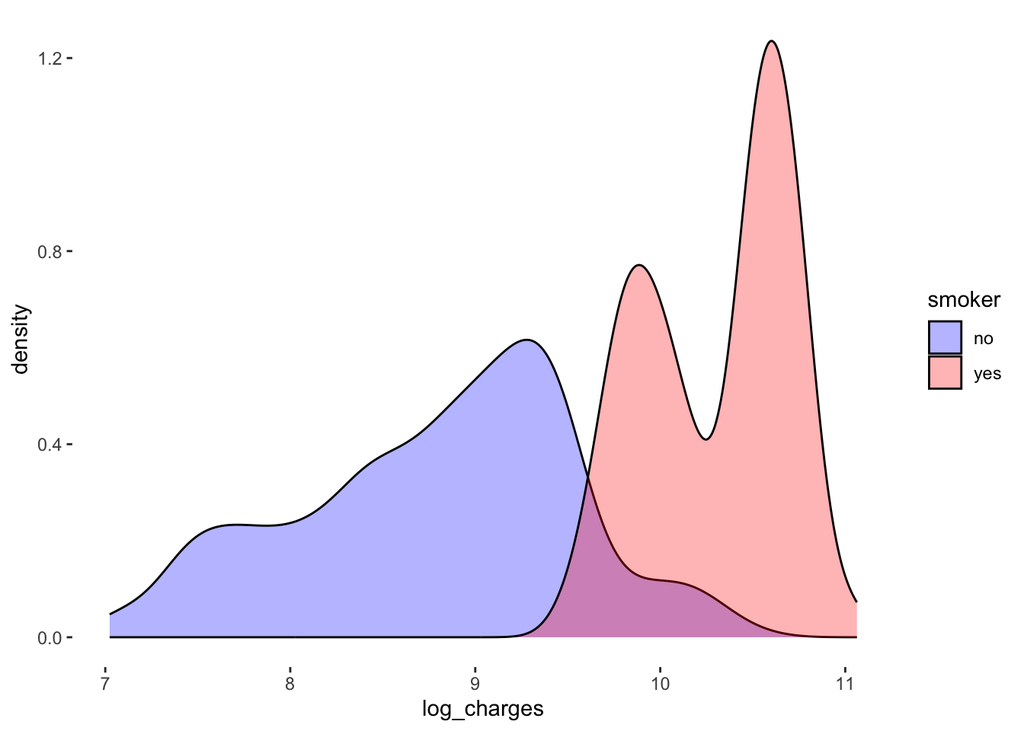

```r
g_9 # Generate plot
```

Here, we see quite a substantial difference in the charges paid by smokers and non-smokers. This is likely to be a quite significant variable.

Finally let’s visualize the relationship between region and charges:

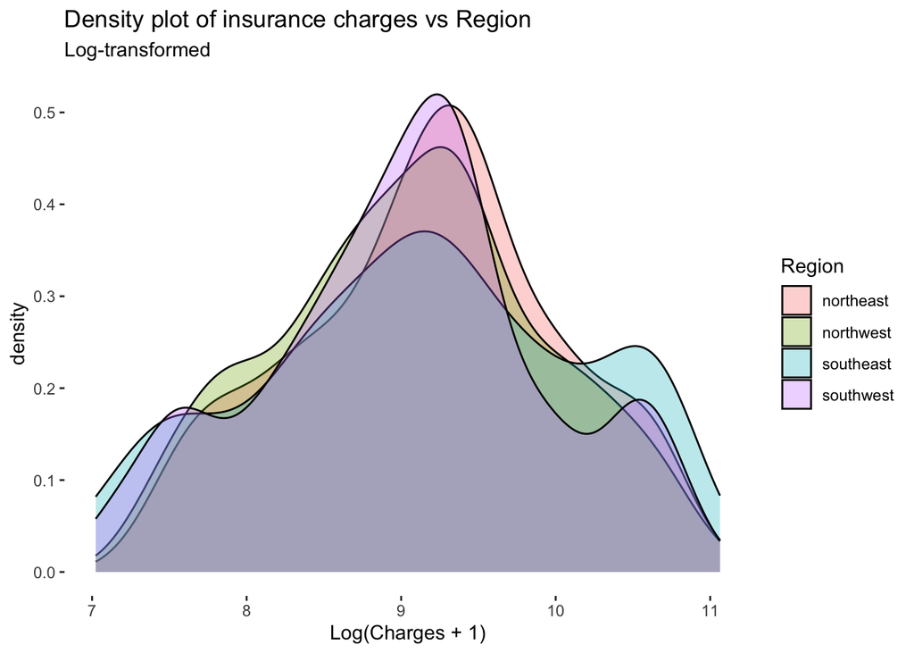

```r
g_10 <- ggplot(insurance, aes(x = log_charges, # Set X-axis as the log of insurance charges
                             fill = region)) + # Set fill as region variable
  geom_density(alpha = 0.3) + # Use geom_density to get density plot
  theme_bw() + # Set theme for plot
  theme(panel.grid.major = element_blank(), # Turn of the background grid
        panel.grid.minor = element_blank(),
        panel.border = element_blank(),
        panel.background = element_blank()) +
  labs(x = "Log(Charges + 1)", # Set plot labels
       title = "Density plot of insurance charges vs Region",
       fill = "Region",
       subtitle = "Log-transformed")

g_10 # Generate plot
```

Lets add these variables to our model, and see what the results look like.

### Multiple Linear Regression

To specify a multiple linear regression model we use the same `lm()` function as before, however, now our formula will be `log_charges ~ age + sex + bmi + children + smoker + region`.

```r
fit_2 <- lm(log_charges ~ age + sex + bmi + children + smoker + region, # Set formula
            data = insurance) # Set dataset
```

Now that we have fitted the linear regression model we again use the `summary()` command to examine the model fit.

```r
summary(fit_2)
```

```
##
## Call:
## lm(formula = log_charges ~ age + sex + bmi + children + smoker +
##     region, data = insurance)
##
## Residuals:
##      Min       1Q   Median       3Q      Max
## -1.07371 -0.19623 -0.04972  0.06656  2.16460
##
## Coefficients:
##                   Estimate Std. Error t value Pr(>|t|)
## (Intercept)      7.0319900  0.0723707  97.166  < 2e-16 ***
## age              0.0345317  0.0008724  39.584  < 2e-16 ***
## sexmale         -0.0745350  0.0244008  -3.055  0.00230 **
## bmi              0.0134005  0.0020953   6.396 2.21e-10 ***
## children         0.1015096  0.0100986  10.052  < 2e-16 ***
## smokeryes        1.5535850  0.0302707  51.323  < 2e-16 ***
## regionnorthwest -0.0620360  0.0349192  -1.777  0.07587 .
## regionsoutheast -0.1572671  0.0350688  -4.485 7.94e-06 ***
## regionsouthwest -0.1289352  0.0350131  -3.682  0.00024 ***
## ---
## Signif. codes:  0 '***' 0.001 '**' 0.01 '*' 0.05 '.' 0.1 ' ' 1
##
## Residual standard error: 0.4441 on 1328 degrees of freedom
## Multiple R-squared:  0.7676, Adjusted R-squared:  0.7662
## F-statistic: 548.4 on 8 and 1328 DF,  p-value: < 2.2e-16
```

Here we see that many of the new variables are significant in our model. With age, bmi, children, and smoker-yes having a positive relationship with the insurance premium. While sex male has a negative relationship.

We have significantly increased the proportion of the variation in insurance charges that we are explaining with the multiple R-squared and adjusted R-squared now having values of 0.768 and 0.766 respectively.

Lets try adding some interaction terms into our model and see if that improves our model fit.

## Interaction terms

Interaction terms are used when we believe that the relationship of one variable and the response variable depends on the value of another variable.

Let’s look again at the relationship between BMI and charges:

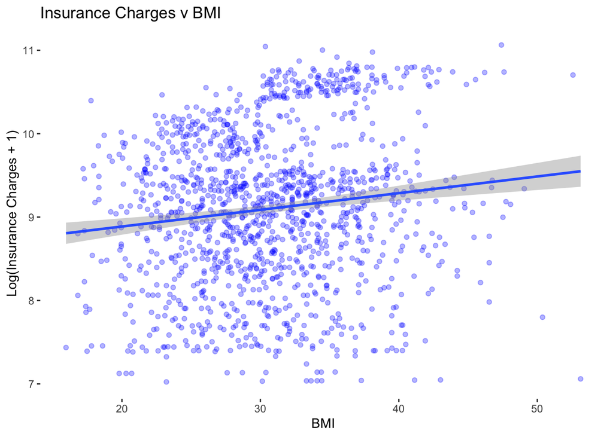

```r
# Create plot
g_11 <- ggplot(insurance, # Set dataset
              aes(y = log_charges, # Set y-axis as insurance charges
                  x = bmi)) + # Set x-axis as bmi.
  geom_point(color = "blue", alpha = 0.3) + # Use geom_point to get scatter plot
  geom_smooth(method = "lm") + # Add smoothing line
  theme_bw() + # Set theme for plot
  theme(panel.grid.major = element_blank(), # Turn of the background grid
        panel.grid.minor = element_blank(),
        panel.border = element_blank(),
        panel.background = element_blank()) +
  labs(y = "Log(Insurance Charges + 1)", # Set plot labels
       x = "BMI",
       title = "Insurance Charges v BMI")

g_11 # Generate plot
```

We saw previously that this was not a strong relationship though it does appear to be positive.

However, if we think that the relationship between BMI and Insurance Premium is different depending on if someone smokes or doesn’t smoke we could also add that to the plot. Let’s see what happens when we color the points on this plot using the smoker variable:

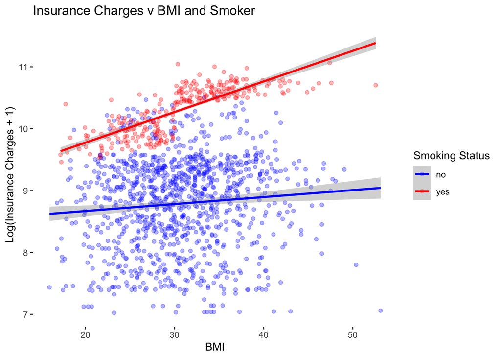

```r
# Create plot
g_12 <- ggplot(insurance, # Set dataset
              aes(y = log_charges, # Set y-axis as insurance charges
                  x = bmi, # Set x-axis as bmi.
                  color = smoker)) +
  geom_point(alpha = 0.3) + # Use geom_point to get scatter plot
  geom_smooth(method = "lm") + # Add smoothing line
  theme_bw() + # Set theme for plot
  theme(panel.grid.major = element_blank(), # Turn of the background grid
        panel.grid.minor = element_blank(),
        panel.border = element_blank(),
        panel.background = element_blank()) +
  scale_color_manual(values =  c("no" = "blue", "yes" = "red")) + # Set color values manually
  labs(y = "Log(Insurance Charges + 1)", # Set plot labels
       x = "BMI",
       color = "Smoking Status",
       title = "Insurance Charges v BMI and Smoker")

g_12 # Generate plot
```

So here we see that when someone smokes there’s a very strong positive relationship between BMI and insurance premium, however if someone doesn’t smoke then the relationship between BMI and insurance premium is still positive but much weaker. So here the relationship between BMI and insurance premium is different depending on the smoking variable. Therefore it would be a good idea to include the smoking * BMI interaction term into a model of insurance premiums.

Let’s add this term to our model and see if we get any improvement in explanatory power. To do this, we multiply the terms in the formula instead of adding them together, our formula is now: `log_charges ~ age + sex + bmi * smoker + children + region`

```r
fit_3 <- lm(log_charges ~ age + sex + bmi * smoker + children + region, # Set formula
            data = insurance) # Set dataset
```

Now that we have fitted the linear regression model we again use the `summary()` command to examine the model fit.

```r
summary(fit_3)
```

```
##
## Call:
## lm(formula = log_charges ~ age + sex + bmi * smoker + children +
##     region, data = insurance)
##
## Residuals:
##      Min       1Q   Median       3Q      Max
## -0.91344 -0.17755 -0.05193  0.04739  2.22141
##
## Coefficients:
##                   Estimate Std. Error t value Pr(>|t|)
## (Intercept)      7.3386448  0.0766432  95.751  < 2e-16 ***
## age              0.0347462  0.0008432  41.209  < 2e-16 ***
## sexmale         -0.0861980  0.0236065  -3.651 0.000271 ***
## bmi              0.0034354  0.0022668   1.516 0.129873
## smokeryes        0.1563102  0.1459375   1.071 0.284330
## children         0.1028083  0.0097583  10.535  < 2e-16 ***
## regionnorthwest -0.0694167  0.0337477  -2.057 0.039888 *
## regionsoutheast -0.1627921  0.0338886  -4.804 1.73e-06 ***
## regionsouthwest -0.1374913  0.0338413  -4.063 5.13e-05 ***
## bmi:smokeryes    0.0455543  0.0046614   9.773  < 2e-16 ***
## ---
## Signif. codes:  0 '***' 0.001 '**' 0.01 '*' 0.05 '.' 0.1 ' ' 1
##
## Residual standard error: 0.4291 on 1327 degrees of freedom
## Multiple R-squared:  0.7832, Adjusted R-squared:  0.7818
## F-statistic: 532.8 on 9 and 1327 DF,  p-value: < 2.2e-16
```

## Other interactions

Let’s try visualizing some others to see if we find any other good potential variables to use.

First we can look at age and bmi. Here as they are two numeric variables we want to visualize the product of the terms. While we can multiply them inside the formula and it will take care of the multiplication for use to visualize them we can create this term outside by multiplying them together.

```r
# Create copy of data
plot_dat <- insurance

# Create interaction term
plot_dat$age_bmi <- insurance$age * insurance$bmi
```

Now let’s visualize this relationship on a scatter plot:

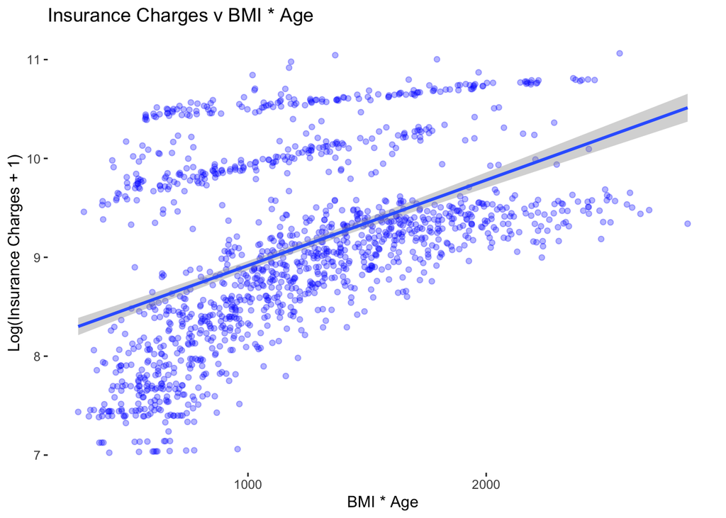

```r
# Create plot
g_13 <- ggplot(plot_dat, # Set dataset
              aes(y = log_charges, # Set y-axis as insurance charges
                  x = age_bmi)) + # Set x-axis as bmi and age
  geom_point(alpha = 0.3, color = "blue") + # Use geom_point to get scatter plot
  geom_smooth(method = "lm") + # Add smoothing line
  theme_bw() + # Set theme for plot
  theme(panel.grid.major = element_blank(), # Turn of the background grid
        panel.grid.minor = element_blank(),
        panel.border = element_blank(),
        panel.background = element_blank()) +
  labs(y = "Log(Insurance Charges + 1)", # Set plot labels
       x = "BMI * Age",
       color = "Smoking Status",
       title = "Insurance Charges v BMI * Age")

g_13 # Generate plot
```

It does look like this may be a significant relationship as there is a positive relationship between the interaction term and the response variable.

Let’s also look at an interaction between smoker and region. For this we can use a box plot to visualize if there are different effects.

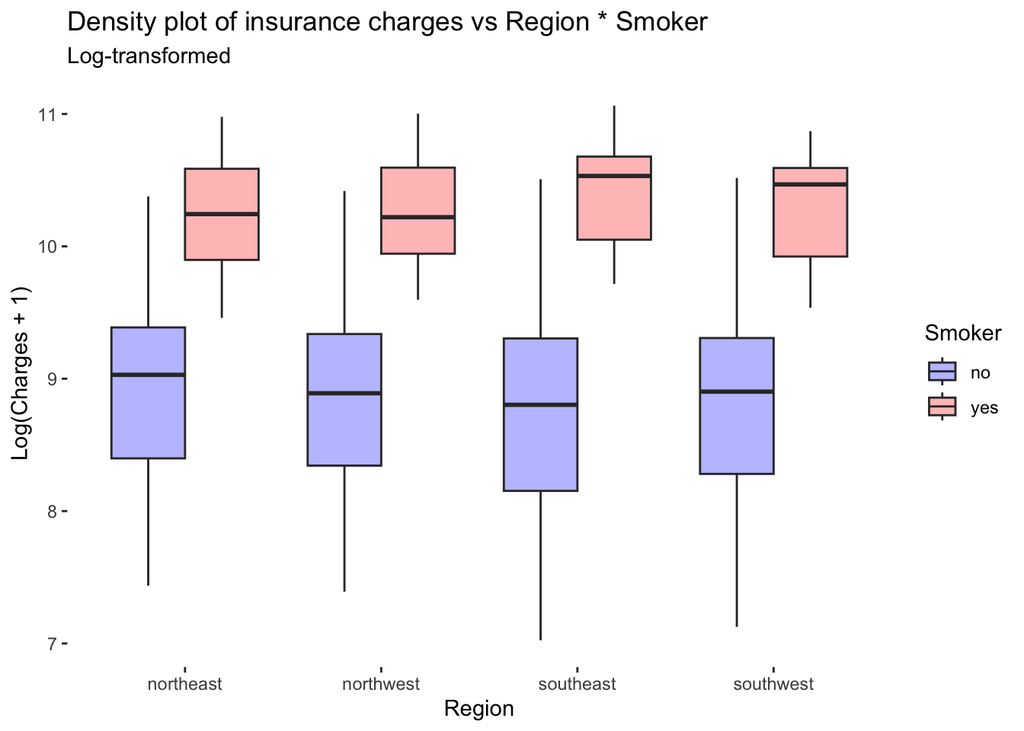

```r
g_14 <- ggplot(insurance, aes(y = log_charges, # Set Y-axis as the log of insurance charges
                              x = region, # Set x-axis as region
                             fill = smoker)) + # Set fill as smoker
  geom_boxplot(alpha = 0.3, position = "dodge") + # Use geom_boxplot to get box plot
  theme_bw() + # Set theme for plot
  theme(panel.grid.major = element_blank(), # Turn of the background grid
        panel.grid.minor = element_blank(),
        panel.border = element_blank(),
        panel.background = element_blank()) +
   scale_fill_manual(values =  c("no" = "blue", "yes" = "red")) + # Set fill values manually
  labs(y = "Log(Charges + 1)", # Set plot labels
       x = "Region",
       title = "Density plot of insurance charges vs Region * Smoker",
       fill = "Smoker",
       subtitle = "Log-transformed")

g_14 # Generate plot
```

Here there does not look to be much change in the relationship between charges and smoker by the different regions, so this is unlikely to be a significant variable.

Let’s try adding both of them to the model and seeing what results we get:

```r
fit_4 <- lm(log_charges ~ age + sex + bmi * smoker + children + region + (region * smoker) + (age * bmi), # Set formula
            data = insurance) # Set dataset
```

Let’s view how the results of the model:

```r
summary(fit_4) # Summarize model 4
```

```
##
## Call:
## lm(formula = log_charges ~ age + sex + bmi * smoker + children +
##     region + (region * smoker) + (age * bmi), data = insurance)
##
## Residuals:
##      Min       1Q   Median       3Q      Max
## -0.91161 -0.17588 -0.05237  0.05203  2.21562
##
## Coefficients:
##                             Estimate Std. Error t value Pr(>|t|)
## (Intercept)                7.1822081  0.1808711  39.709  < 2e-16 ***
## age                        0.0389832  0.0043228   9.018  < 2e-16 ***
## sexmale                   -0.0877010  0.0235773  -3.720 0.000208 ***
## bmi                        0.0090369  0.0058052   1.557 0.119785
## smokeryes                  0.1488051  0.1516981   0.981 0.326807
## children                   0.1029248  0.0097416  10.565  < 2e-16 ***
## regionnorthwest           -0.0729467  0.0374652  -1.947 0.051740 .
## regionsoutheast           -0.1864122  0.0384218  -4.852 1.37e-06 ***
## regionsouthwest           -0.1783496  0.0375349  -4.752 2.24e-06 ***
## bmi:smokeryes              0.0430500  0.0048702   8.839  < 2e-16 ***
## smokeryes:regionnorthwest  0.0044248  0.0855259   0.052 0.958747
## smokeryes:regionsoutheast  0.1080212  0.0813075   1.329 0.184225
## smokeryes:regionsouthwest  0.2226388  0.0861747   2.584 0.009885 **
## age:bmi                   -0.0001349  0.0001373  -0.983 0.325868
## ---
## Signif. codes:  0 '***' 0.001 '**' 0.01 '*' 0.05 '.' 0.1 ' ' 1
##
## Residual standard error: 0.4282 on 1323 degrees of freedom
## Multiple R-squared:  0.7848, Adjusted R-squared:  0.7827
## F-statistic: 371.2 on 13 and 1323 DF,  p-value: < 2.2e-16
```

Here we see that there has not been much adjustment in the multiple and adjusted R-squared values in our model. Our age*bmi interaction did not end up being very significant while one of the region*smoker terms did end up being significant.

## Higher Order Interactions

We can also create higher level interaction terms by multiplying multiple terms together:

```r
fit_5 <- lm(log_charges ~  sex + children + bmi * smoker * age * region, # Set formula
            data = insurance) # Set dataset
```

Let’s view how the results of the model:

```r
summary(fit_5) # Summarize model 5
```

```
##
## Call:
## lm(formula = log_charges ~ sex + children + bmi * smoker * age *
##     region, data = insurance)
##
## Residuals:
##      Min       1Q   Median       3Q      Max
## -0.69124 -0.15784 -0.06371  0.00325  2.44532
##
## Coefficients:
##                                     Estimate Std. Error t value Pr(>|t|)
## (Intercept)                        6.480e+00  3.690e-01  17.558  < 2e-16 ***
## sexmale                           -8.352e-02  2.123e-02  -3.935 8.77e-05 ***
## children                           1.046e-01  8.814e-03  11.863  < 2e-16 ***
## bmi                                3.080e-02  1.243e-02   2.477   0.0134 *
## smokeryes                          1.377e+00  7.525e-01   1.830   0.0675 .
## age                                5.213e-02  9.021e-03   5.779 9.38e-09 ***
## regionnorthwest                    7.507e-01  5.373e-01   1.397   0.1626
## regionsoutheast                    6.610e-01  5.210e-01   1.269   0.2048
## regionsouthwest                   -1.338e-01  5.105e-01  -0.262   0.7933
## bmi:smokeryes                      4.013e-02  2.593e-02   1.547   0.1220
## bmi:age                           -5.269e-04  2.988e-04  -1.763   0.0781 .
## smokeryes:age                     -3.197e-02  1.981e-02  -1.614   0.1068
## bmi:regionnorthwest               -3.097e-02  1.826e-02  -1.696   0.0901 .
## bmi:regionsoutheast               -3.901e-02  1.647e-02  -2.368   0.0180 *
## bmi:regionsouthwest               -1.319e-02  1.709e-02  -0.772   0.4405
## smokeryes:regionnorthwest         -1.158e+00  1.346e+00  -0.861   0.3894
## smokeryes:regionsoutheast         -1.556e-01  1.038e+00  -0.150   0.8809
## smokeryes:regionsouthwest          1.067e-01  1.270e+00   0.084   0.9331
## age:regionnorthwest               -1.610e-02  1.324e-02  -1.215   0.2245
## age:regionsoutheast               -8.930e-03  1.279e-02  -0.698   0.4853
## age:regionsouthwest                5.666e-03  1.235e-02   0.459   0.6465
## bmi:smokeryes:age                  7.782e-05  6.674e-04   0.117   0.9072
## bmi:smokeryes:regionnorthwest      4.188e-02  4.595e-02   0.911   0.3623
## bmi:smokeryes:regionsoutheast      1.723e-02  3.328e-02   0.518   0.6046
## bmi:smokeryes:regionsouthwest      1.074e-02  4.135e-02   0.260   0.7951
## bmi:age:regionnorthwest            6.167e-04  4.434e-04   1.391   0.1645
## bmi:age:regionsoutheast            5.960e-04  3.989e-04   1.494   0.1353
## bmi:age:regionsouthwest            1.000e-04  4.039e-04   0.248   0.8045
## smokeryes:age:regionnorthwest      2.266e-02  3.378e-02   0.671   0.5025
## smokeryes:age:regionsoutheast      2.911e-03  2.615e-02   0.111   0.9114
## smokeryes:age:regionsouthwest     -9.415e-03  3.397e-02  -0.277   0.7817
## bmi:smokeryes:age:regionnorthwest -8.028e-04  1.140e-03  -0.704   0.4815
## bmi:smokeryes:age:regionsoutheast -3.043e-04  8.332e-04  -0.365   0.7150
## bmi:smokeryes:age:regionsouthwest  7.916e-05  1.084e-03   0.073   0.9418
## ---
## Signif. codes:  0 '***' 0.001 '**' 0.01 '*' 0.05 '.' 0.1 ' ' 1
##
## Residual standard error: 0.3833 on 1303 degrees of freedom
## Multiple R-squared:  0.8302, Adjusted R-squared:  0.8259
## F-statistic: 193.1 on 33 and 1303 DF,  p-value: < 2.2e-16
```